# A New Measurement of Educational Social Mobility: Application to a Global Dataset

Khanh Duong

2025-03-11

[figure not shown]

[Paper link](https://doi.org/10.1016/j.strueco.2025.02.014)

**Acknowledgment:** This research draws on the knowledge gained from my PhD courses with Prof. Bart Verspagen and Dr. Tommaso Ciarli, as well as discussions with my PhD colleagues Derek Scolnick, Raghav Sridhar Chakravarthy, and Matilde João Mota. I also benefited from the valuable feedback provided by my supervisors, Prof. Wim Groot and Prof. Kristof de Witte. I would like to express my gratitude to editor Prof. James K. Galbraith for his very encouraging comments on this research, as well as to the reviewers for their insightful feedback.

[figure not shown]

# New database, New report

[figure not shown]

[figure not shown]

- **Intergenerational economic mobility** is crucial for human progress.
- Parents aspire for their children to achieve a **higher living standard**.
- **Public policy** plays a key role in enabling upward mobility.
- **Barriers to mobility** remain significant, especially in developing countries.
- Moving up the **economic ladder** is often harder in poorer nations than in wealthier ones.

## Is this a fair progress?

- **Economic opportunities** are often determined by **factors beyond individual control**, such as parental wealth and education.
- **IGM is unequal across societies**, with disadvantaged individuals facing limited chances for upward mobility.
- This **violates equality of opportunity**, where success should depend on **effort and talent**, not inherited advantages.

# The problem of measurement?

**Absolute mobility** is measured by the proportion of individuals who attain a higher level of education than the maximum educational attainment of their parents.

-> Absolute: Higher - better

**Relative immobility (Intergenerational persistence)** is quantified by the coefficient from a regression that predicts children’s years of schooling based on the years of schooling of their parents.

-> Relative: Lower - better

## Does Maldives make more progress of education than Canada?

**Is it true to say C5P5 has no progress?**

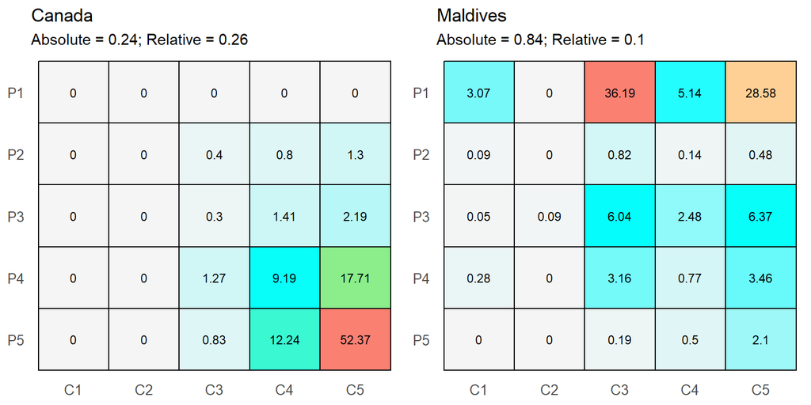

## Does South Sudan make the same progress of education as Taiwan?

**They are have the quite similar value of relative immobility.**

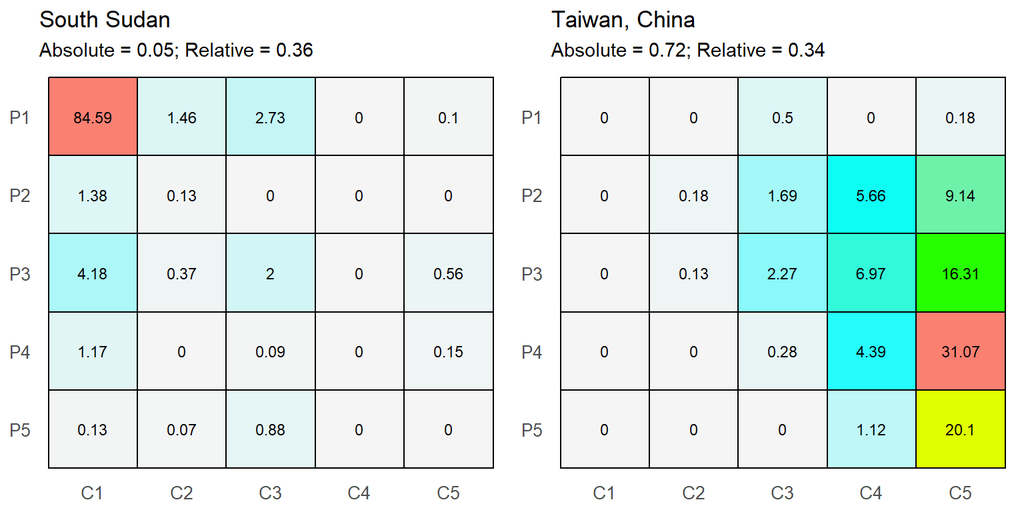

**The gap:**

- **Relative intergenerational mobility (IGM)**, derived from tegressing individuals’ education on their parents’ education, **does not differentiate between upward and downward mobility**.
- **Absolute mobility** measures the proportion of individuals with higher educational attainment than their parents, but it doesn’t capture the **relative position** within the same generation.

  For example, individuals born to parents with low education might **surpass their parents’ education** but still fail to reach the **top tiers of educational achievement** in their generation.

# What does the ideal matrix look like?

We begins with the original distribution in the parent generation, where the probabilities are as follows: $P_1$ for ISCED 0 $P_2$ for ISCED 1, $P_3$ for ISCED 2 $P_4$ for ISCED 3 and $P_5$ for ISCED 5-8.

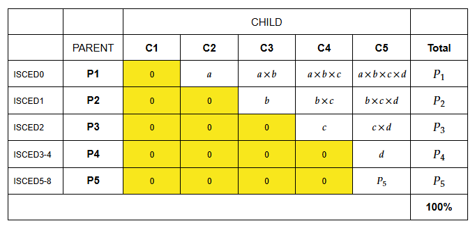

$$\begin{array}{l}
\begin{cases}
a + a \times b + a \times b \times c + a \times b \times c \times d =
P_1 < 1 \\
b + b \times c + b \times c \times d = P_2 < 1 \\
c + c \times d = P_3 < 1 \\
d = P_4 < 1
\end{cases} \\
\Rightarrow
\begin{cases}
a = \frac{P_1}{1 + P_2} < 1 \\
b = \frac{P_2}{1 + P_3} < 1 \\
c = \frac{P_3}{1 + P_4} < 1 \\
d = P_4 < 1
\end{cases}
\end{array}$$

**Total variation distance** in Information theory:

$$D_{\text{TV}} = \frac{1}{2} \sum_{x} |P(x) - Q(x)|$$

where $P(x)$ is the ideal matrix and $Q(x)$ is the actual matrix.

**-> The progress gap** is defined based on the Total Variation distance:

$$D_{\text{PG}} = \frac{1}{2} \sum_{x \in U} P(x) - Q(x) - \frac{1}{2}
\sum_{x \notin U} P(x) - Q(x)$$

Here, $c$ represents the child education level and $p$ represents the maximum parent education level.

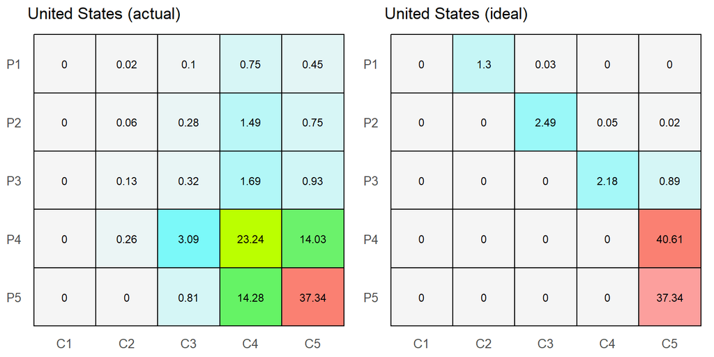

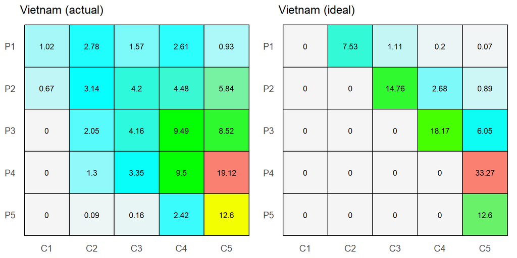

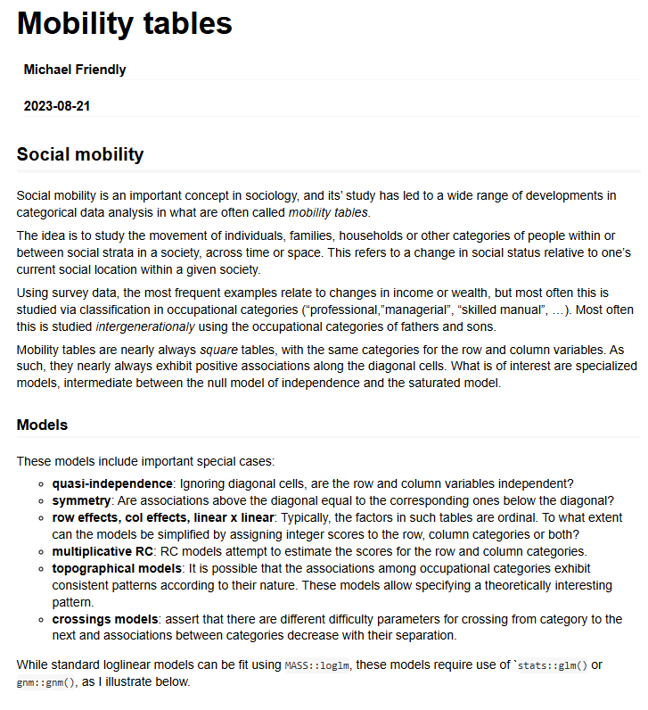

# Ranking country in terms of Progress Gap

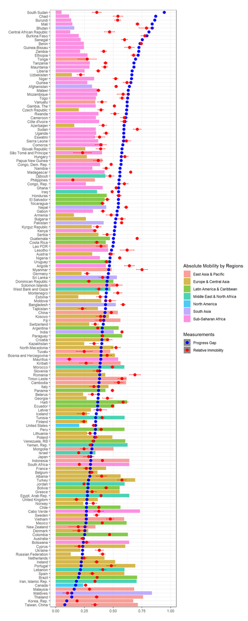

# Compare to Absolute Mobility

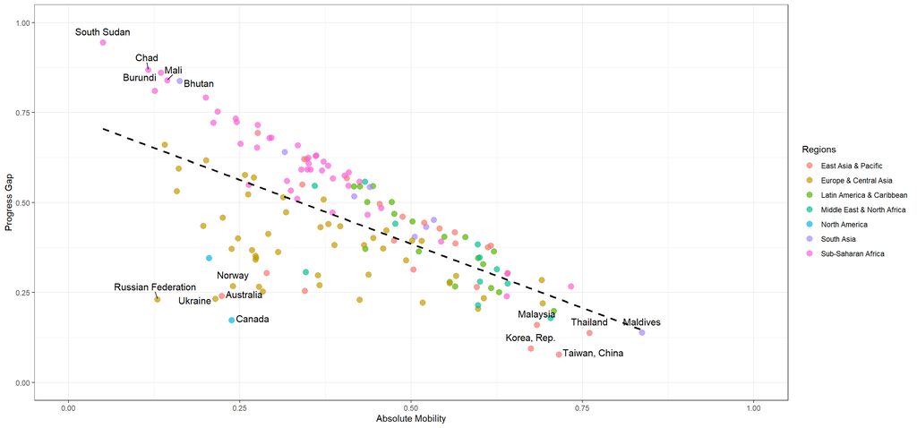

## Same Absolute Mobility

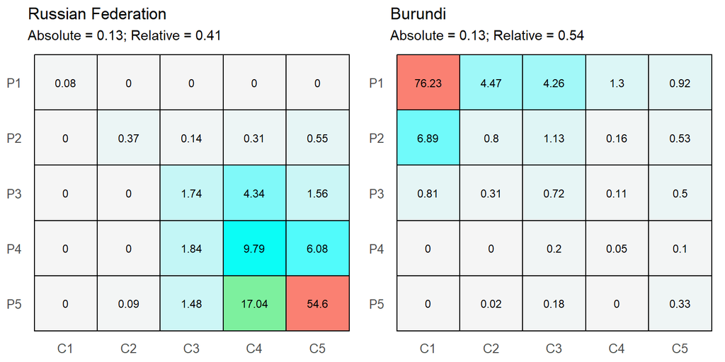

## Same Progress Gap

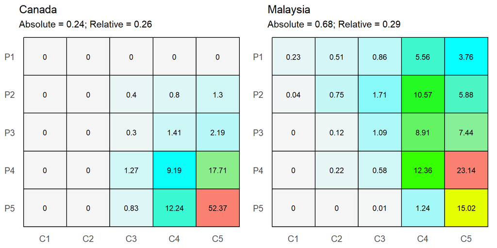

# Compare to Relative Immobility

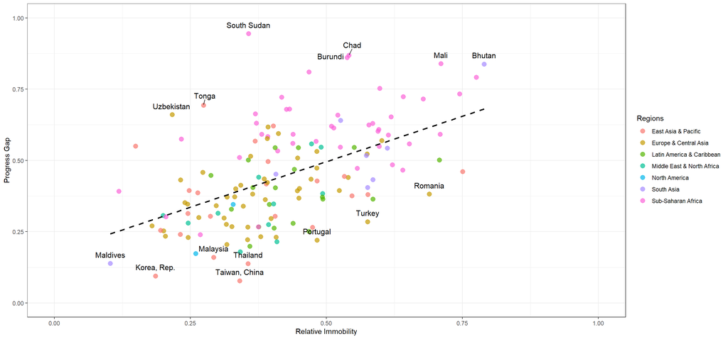

## Same Relative Immobility

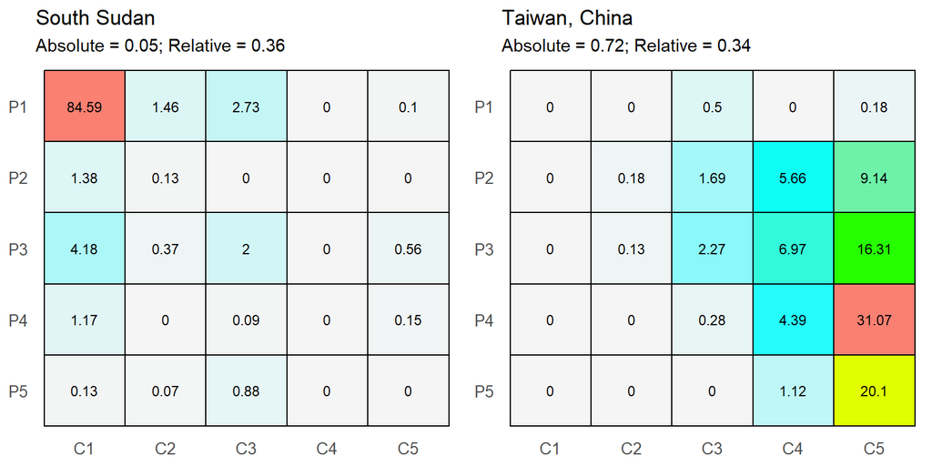

## Same Progess Gap

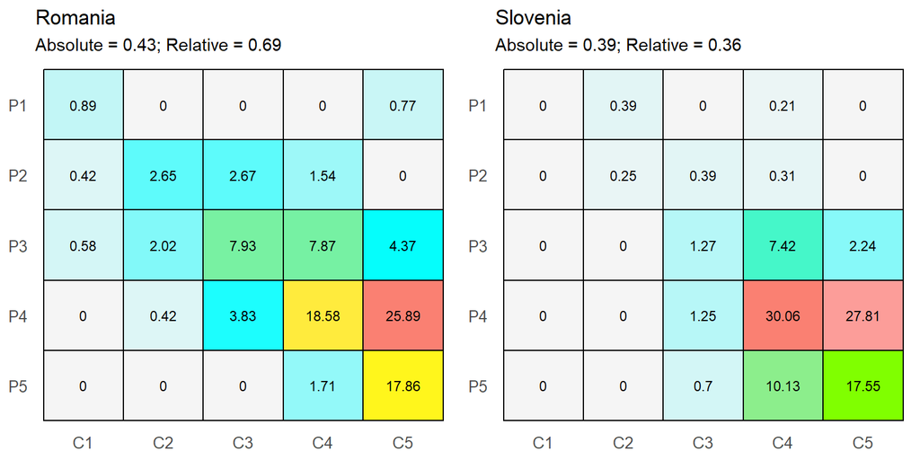